# Data Science With an Eye Towards Sustainability P7: Project Check-In and Research Questions Update

Gabrielle Arrache and Naomi Francis

It is time for another project checkpoint. By now, your research questions should be significantly narrowed, and you should be well on your way to developing some visualizations to answer at least some of the research questions. **Each group should hand in one html document for the following exercises.**

# 1 Names & Workflow

List all group members. Discuss a plan for completing this assignment. How will you put together your shared Rmd? How will you divide the work? When will you meet to work on the assignment? Write this down in your Rmd.

Also, if you are using one, write down your GitHub repository.

We are using Github to work on shared RMD. Github Repository: https://github.com/olincollege/food-security-education/ We are meeting either on Tuesday, Thursday or Sundays to work on the project.

# 2 Team Health and Progress

Please take a few minutes to reflect collectively on how things have been going so far in terms of working together as a team. What has worked well? What hasn’t? Are there work flow changes you want to make for the remainder of the project?

Our meetings have been working well to get work done and decide on model settings together, ensuring alignment. We have also created a Trello board to track progress, plan, and see what each person is working on.

Trello Link: https://trello.com/invite/b/69de7c8026a66b1794048655/ATTI221ae1fce3cd2eb600d16aa7b1d896a80726A1C1/data-science-project

# 3 Refined Research Questions

Please specify your updated research question(s) here. At this point, I am expecting 1-4 research questions that are more closely connected.

1. What factors in a child’s life most significantly impact their grades?
- can have specific sub questions if needed

# 4 Connections to Sustainability

How are your research questions connected to sustainability? What are your personal learning goals related to sustainability for this project? You may wish to refer back to the [UN Sustainable Development Goals](https://sdgs.un.org/goals), the [Inner Development Goals](https://innerdevelopmentgoals.org/), and the [Engineering for One Planet](https://engineeringforoneplanet.org/wp-content/uploads/EOP_Framework_2023.pdf?), [Six Pillars of Climate Justice](https://centerclimatejustice.universityofcalifornia.edu/what-is-climate-justice/), and [Just Transition Principles](https://climatejusticealliance.org/just-transition/) frameworks. As a team, what sustainability background, analysis, and storytellling do you want to include in the scope of your project and in your final artifacts?

According to Hannah Ritchie, sustainability means providing a good quality of life for people today while protecting the future. However, many children in the US still experience food insecurity, which shows that this goal is not being achieved. This topic connects to UN SDG #2 (Zero Hunger) and SDG #4 (Quality Education), and we are addressing how proper nutrition affects people early in life. By investigating the relationships between food security and educational performance, we can highlight the importance of nutrition and sources of high nutrition. As a team, our goal is to better understand how inequalities like food insecurity impact education and long-term opportunities. We want to include data analysis and storytelling that make these inequalities visible and easier to understand. Our project aims to understand whether children are living sustainable today, and to explore how access to food and education may influence more sustainable futures. Through exploration of our data so far, we’ve noticed a seemingly positive correlation between food security and academic performance. Knowing that grades can sometimes help with obtaining careers through scholarships, internships, and access to education, we are making a connection between sustainability in children’s lives today and sustainability in their future.

# 5 Data

# 6 Research Question 1

Restate research question 1. Construct 3-4 relevant visualizations that provide insight on / help answer this question and piece these together to tell a short story. For each visualization, 1-2 sentences will suffice.

1. What factors in a child’s life most significantly impact their grades?

```r
library(readr)

df_23_24 <- read_csv("data/raw/2023-2024_NSCH_Topical_CAHMI_DRC.csv")
df_21_22 <- read_csv("data/raw/2021-2022 NSCH_Topical_DRC_CAHMI_v3.csv")
df_20 <- read_csv("data/raw/NSCH_2020e_Topical_CAHMI_DRCv3.csv")
df_18_19 <- read_csv("data/raw/NSCH_2018e_2019e_Topical_CAHMI_DRCv3.csv")
library(dplyr)
#select variables of interest

#had to remove race7_2324
allfactors_23_24 <- df_23_24 |>
  select(grades6to11_2324, ChHlthSt_2324, LowBWght_2324, PhysAct_2324, Cond2more_2324, CSHCN_2324, ADHDind_2324, ADHDSevInd_2324, ASDSevInd_2324, bullied_2324, bully_2324, MakeFriend_2324, MEDB10ScrQ5_2324, MedCare_2324, MentHCare_2324, SpEducPln_2324, ReptGrade_2324, povlev4_2324, age5_2324, sex_2324, FoodSit_2324, FoodCash_2324)

allfactors_21_22 <- df_21_22 |>
  select(SchlEngage_2122, ChHlthSt_2122, LowBWght_2122, PhysAct_2122, Cond2more_2122, CSHCN_2122, ADHDind_2122, ADHDSevInd_2122, ASDSevInd_2122, bullied_2122, bully_2122, MakeFriend_2122, MEDB10ScrQ5_2122, MedCare_2122, MentHCare_2122, SpEducPln_2122, ReptGrade_2122, povlev4_2122, race7_2122, age5_2122, sex_2122, FoodSit_2122, FoodCash_2122)

allfactors_20 <- df_20 |>
  select(SchlEngage_20, ChHlthSt_20, LowBWght_20, PhysAct_20, Cond2more_20, CSHCN_20, ADHDind_20, ADHDSevInd_20, ASDSevInd_20, bullied_20, bully_20, MakeFriend_20, MEDB10ScrQ5_20, MedCare_20, MentHCare_20, SpEducPln_20, ReptGrade_20, povlev4_20, race7_20, age5_20, sex_20, FoodSit_20, FoodCash_20)

#no medcare variable in this dataset
allfactors_18_19 <- df_18_19 |>
  select(SchlEngage_1819, ChHlthSt_1819, LowBWght_1819, PhysAct_1819, Cond2more_1819, CSHCN_1819, ADHDind_1819, ADHDSevInd_1819, ASDSevInd_1819, bullied_1819, bully_1819, MakeFriend_1819, MEDB10ScrQ5_1819, MentHCare_1819, SpEducPln_1819, ReptGrade_1819, povlev4_1819, race7_1819, age5_1819, sex_1819, FoodSit_1819, FoodCash_1819)

df_23_24 <- df_23_24[complete.cases(df_23_24), ]
df_21_22 <- df_21_22[complete.cases(df_21_22), ]
df_20 <- df_20[complete.cases(df_20), ]
df_18_19 <- df_18_19[complete.cases(df_18_19), ]
```

```r
#are we joining all years together? are we joining ages as well?

library(ggplot2)

# clean the data for the visualization
allfactors_23_24 <- allfactors_23_24 |>
  filter(!Cond2more_2324==99) |> # filter out missing values in Cond2more_2324
  filter(grades6to11_2324 %in% c(1, 2, 3, 4)) |>  # filter out missing values/no grade in grades6to11_2324
  filter(FoodSit_2324 %in% c(1, 2, 3, 4)) |>
  mutate(Cond2more_2324 = as.character(Cond2more_2324))

# interpret the number meaning of the grade
grade_meaning = tibble(grade_code = c(1, 2, 3, 4), grade_meaning = c("Mostly A's", "Mostly A's and B's", "Mostly B’s and C’s", "Mostly C's and D's or lower"))

allfactors_23_24 <- allfactors_23_24 |>
  left_join(grade_meaning, by = join_by(`grades6to11_2324` == `grade_code`))

# interpret the number meaning of the condition status
condition_meaning = tibble(condition_code = c("1", "2", "3"), condition_meaning = c("Does not have condition", "Ever told, but no current condition", "Currently has condition"))

allfactors_23_24 <- allfactors_23_24 |>
  left_join(condition_meaning, by = join_by(`Cond2more_2324` == `condition_code`))

foodsecurity_meaning = tibble(foodsecurity_code = c(1, 2, 3, 4), food_situation = c("Always get enough nutritious food", "Always enough food but not nutritious", "Sometimes not enough food", "Often not enough"))

allfactors_23_24 <- allfactors_23_24 |>
  left_join(foodsecurity_meaning, by = join_by("FoodSit_2324" == "foodsecurity_code"))
```

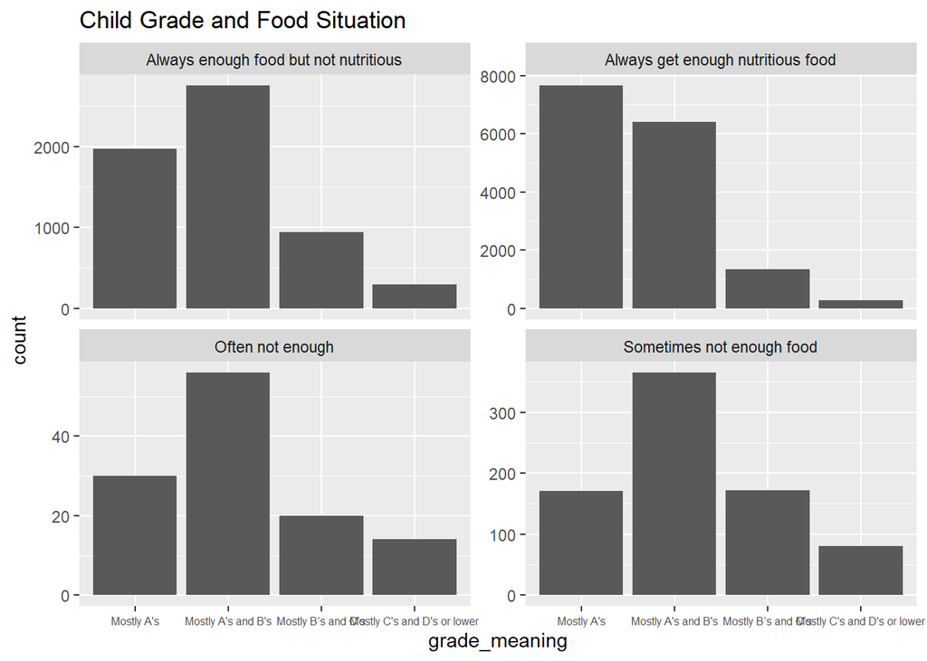

```r
library(ggplot2)
library(forcats)

# food security and grade
ggplot(allfactors_23_24, aes(x = grade_meaning))+
  geom_bar()+
  facet_wrap(~food_situation, scales = "free_y")+
  theme(axis.text.x = element_text(size = 6))+
  labs(title = "Child Grade and Food Situation")
```

```r
# child health condition and grade visual
allfactors_23_24 <- allfactors_23_24 |>
  group_by(condition_meaning) |>
  mutate(condition_meaning = fct_relevel(condition_meaning, "Does not have condition", "Ever told, but no current condition", "Currently has condition")) |>
  group_by(food_situation) |>
  mutate(food_situation = fct_relevel(food_situation, "Always get enough nutritious food", "Always enough food but not nutritious", "Sometimes not enough food", "Often not enough"))
```

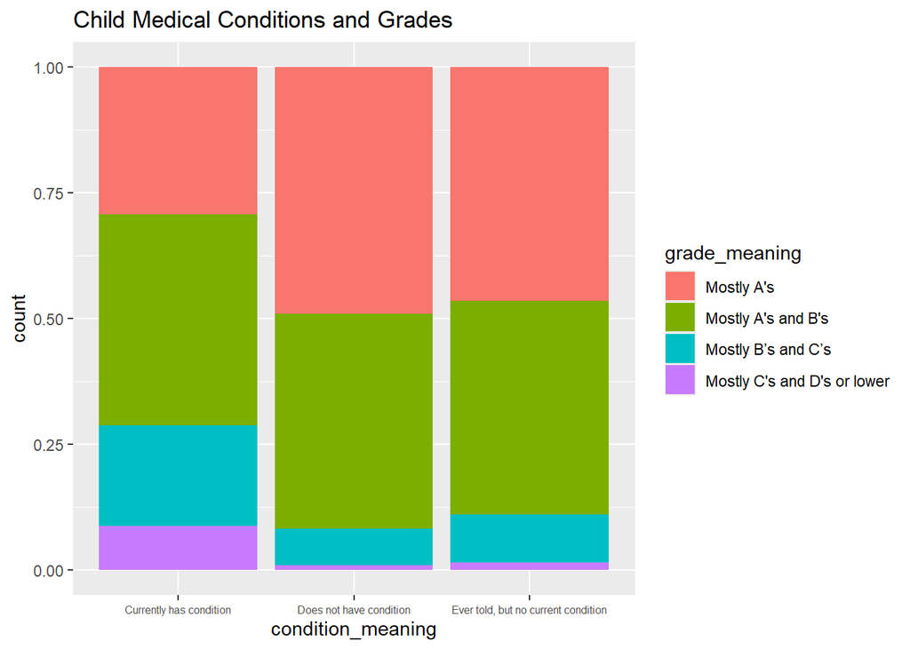

```r
ggplot(allfactors_23_24, aes(x = condition_meaning, fill = grade_meaning))+
  geom_bar(position = "fill")+
  theme(axis.text.x = element_text(size = 6))+
  labs(title = "Child Medical Conditions and Grades")
```

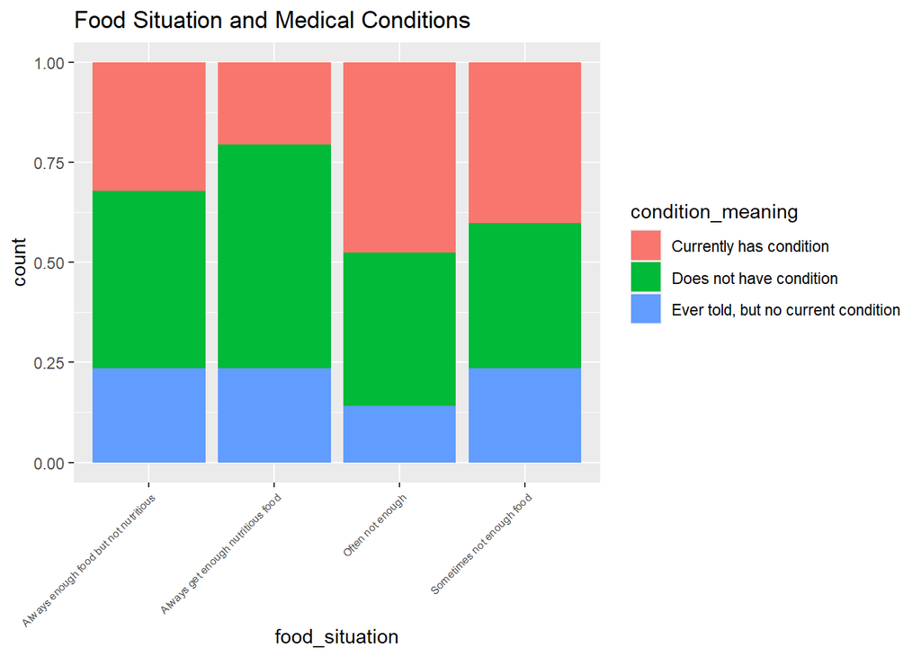

```r
#looking at food security vs condition
ggplot(allfactors_23_24, aes(x = food_situation, fill = condition_meaning))+
  geom_bar(position = "fill")+
  theme(axis.text.x = element_text(size = 6, hjust = 1, vjust = 1, angle = 45))+
  labs(title = "Food Situation and Medical Conditions")
```

The first visualization shows that more children who are always food secure receive mostly A’s than any other grading bracket. For every other category of food security, this is not true.

The second visualization shows that students with a condition such as allergies, autoimmune diseases, Down syndrome, anxiety problems, depression, speech and language problems, and ADHD have a higher proportion of students with lower grades.

The third visualization shows that there is a higher proportion of children with a medical condition that are also food insecure than children who are food secure. This suggests that children dealing with food insecurity are more likely to experience a medical condition that may hinder their learning.

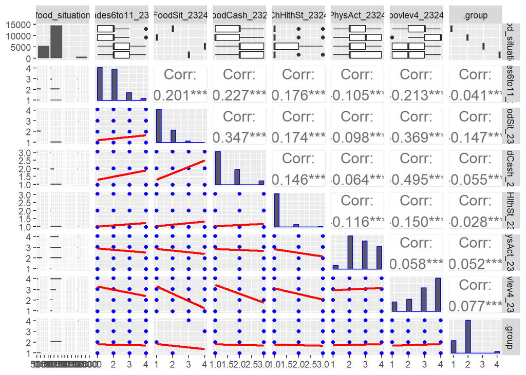

```r
library(ggplot2)
library(GGally)


df_23_24_clean <- allfactors_23_24 %>%
  filter(if_all(everything(), ~ . != 99)) %>% # removes rows that contain 99
  select(
    grades6to11_2324,
    FoodSit_2324,
    FoodCash_2324,
    ChHlthSt_2324,
    PhysAct_2324,
    povlev4_2324
  )
lowerFn <- function(data, mapping, method = "lm", ...) {
  ggplot(data = data, mapping = mapping) +
    geom_point(colour = "blue", alpha = 0.4) +
    geom_smooth(method = method, color = "red", se = FALSE, ...)
}

ggpairs(
  df_23_24_clean,
  lower = list(continuous = wrap(lowerFn, method = "lm")),
  diag = list(continuous = wrap("barDiag", colour = "blue", bins = 10)),
  upper = list(continuous = wrap("cor", size = 5))
)
```

# 7 Next Steps

Identify next steps in your analysis. Do you need additional data? Do you need to do more cleaning or wrangling? Do you need to do some statistical modeling and inference? What additional visualizations would be helpful? How are the stories coming together?  
No additional data is needed, as we will be working with the National Survey of Children’s Health dataset across multiple years.

However, we still need data cleaning and wrangling. We need to handle different types of missing or non-substantive responses. For example, values such as 6, 7, 95, and 99 can represent “don’t know,” or “refused,”, and should be excluded from the analysis depending on the variable. We also need to ensure consistency across years, since some variables can have different names, formats, or coding schemes.

The next step in the analysis will involve statistical modeling and variable selection. We plan to use methods such as ANOVA and Lasso regression to identify the most relevant predictors of grades.

In terms of visualization, additional plots such as boxplots and regression plots would be helpful to further explore relationships between key variables and correlations.

From our initial exploration, we are already observing some patterns. There appears to be a relationship between children’s health conditions and their grades, as well as between food insecurity and both grades and health conditions.

# 8 Contributions

Summarize each group member’s specific contributions to this checkpoint assignment.

Both: Connections to sustainability and figuring out Github.

Naomi: Created visualizations surrounding research question 1.

Gabi: Loading the data in a reproducible way considering access restrictions and size constraints using gitignore. Created a data folder with the downloaded data and codebooks. GGpairs visualization.